# Assignment 2 Data-505

Author

Ghson Alotibi

Published

February 2, 2025

**Abstract:**

This blog post walks through the process of feature engineering, model training, and evaluation using a wine dataset. The post is available as both an HTML file and a .qmd file hosted on GitHub Pages. The code and explanations are provided in R, utilizing libraries such as tidyverse, caret, and fastDummies.

**Step Up Code:**

```r
library(tidyverse)
library(caret)
library(fastDummies)
wine <- readRDS(gzcon(url("https://github.com/cd-public/D505/raw/master/dat/wine.rds")))
```

**Explanataion:**

> : *- library(tidyverse): Loads the tidyverse package for data manipulation and visualization - library(caret): Loads the caret package for machine learning workflows - library(fastDummies): Loads package for creating dummy variables - The last line loads the wine dataset from a GitHub URL using gzcon*

# Feature Engineering

We begin by engineering an number of features.

1. Create a total of 10 features (including points).
2. Remove all rows with a missing value.
3. Ensure only log(price) and engineering features are the only columns that remain in the `wino` dataframe.

```r
# Create engineered features
wino <- wine %>%
    # Create log price
    mutate(lprice = log(price)) %>%
    # Feature 1: Standardized points
    mutate(std_points = scale(points) %>% as.vector) %>%
    # Feature 2: High-end wine flag (price > 50)
    mutate(is_premium = price > 50) %>%
    # Feature 3: Word count in description
    mutate(description_length = str_count(description, '\\w+')) %>%
    # Feature 4: Country grouping
    mutate(country = fct_lump(country, 5)) %>%
    # Feature 5: Major variety flag
    mutate(major_variety = fct_lump(variety, 3)) %>%
    # Feature 6: Has designation
    mutate(has_designation = !is.na(designation)) %>%
    # Feature 7: Province grouping
    mutate(major_province = fct_lump(province, 4)) %>%
    # Feature 8: Description mentions "rich" or "complex"
    mutate(is_complex = str_detect(tolower(description), "rich|complex")) %>%
    # Feature 9: Description sentiment (mentions "excellent" or "outstanding")
    mutate(positive_review = str_detect(tolower(description), "excellent|outstanding")) %>%
    # Convert categorical variables to dummies
    dummy_cols(select_columns = c("country", "major_variety", "major_province")) %>%
    # Select final features and remove NA
    select(lprice, std_points, is_premium, description_length,
           has_designation, is_complex, positive_review,
           starts_with("country_"), starts_with("major_variety_"),
           starts_with("major_province_")) %>%
    drop_na()
```

# Caret

We now use a train/test split to evaluate the features.

1. Use the Caret library to partition the wino dataframe into an 80/20 split.
2. Run a linear regression with bootstrap resampling.
3. Report RMSE on the test partition of the data.

```r
# Create train/test split
set.seed(123)  # for reproducibility
train_index <- createDataPartition(wino$lprice, p = 0.8, list = FALSE)
train_data <- wino[train_index, ]
test_data <- wino[-train_index, ]
```

```r
# Train model with bootstrap resampling
model <- train(
    lprice ~ .,
    data = train_data,
    method = "lm",
    trControl = trainControl(
        method = "boot",
        number = 25
    )
)
```

```r
# Test set performance
# Calculate RMSE on test data
predictions <- predict(model, test_data)
test_rmse <- sqrt(mean((test_data$lprice - predictions)^2))
print(paste("Test RMSE:", round(test_rmse, 4)))
```

```
[1] "Test RMSE: 0.3808"
```

# Variable selection

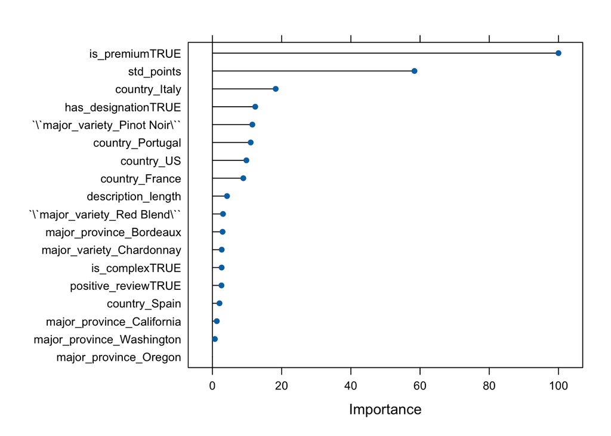

```r
# Variable importance
importance <- varImp(model, scale = TRUE)
plot(importance)
```